# Síndrome Metabólico

Daruich, Nicolás Alberto

2024-02-07

## Sobre las entregas

1er DESAFÍO:  
- Crear un **R Markdown**, utilizar tu dataset seleccionado. El reporte debe contener por lo menos una tabla que *resulte de una sumarización agrupada* para mostrar un resumen interesante de la información. - Generar por lo menos dos visualizaciones que permitan apreciar la relación entre dos o más variables del dataset con ggplot2.  
- Definir una función que describa las dimensiones del dataset como así también si existen datos NA, la función debe retornar un mensaje en la consola indicando número de filas, columnas y total de NAs si es que existen. - Pre-Wrangling  
- Post-Wrangling

2do DESAFÍO:  
- Análisis de Componentes Principales

## Justificación

1. Relevancia clínica: El **síndrome metabólico** es un conjunto de condiciones médicas que aumentan el riesgo de **enfermedades cardiovasculares** y **diabetes tipo 2**. Al trabajar con un DataFrame que contenga datos relacionados con el síndrome metabólico, se podrá **explorar** y **analizar** información clínicamente relevante, lo que brindará una introducción práctica a la aplicación de R en el análisis de datos de salud.
2. Aplicación práctica de R: Proporciona la oportunidad de aplicar los conceptos y técnicas aprendidas en R a un contexto real. Esto incluye la **importación** de datos, **limpieza**, **manipulación** y **visualización**, habilidades esenciales para cualquier analista de datos.
3. Multidisciplinario: Al involucrar fenómenos médicos, nutricionales y de estilo de vida, combina varias disciplinas a través de las variables de interés. Por lo tanto, es una oportunidad de ingresar a la naturaleza interdisciplinaria del análisis de datos. La **integración disciplinaria** favorece ademas el desarrollo de habilidades transferibles.
4. Motivación intrínseca: Dado mi **interés personal** en la medicina.

## Resúmen

### Concepto

El síndrome metabólico (SM) consiste en una **agrupación de alteraciones metabólicas** que confieren un elevado riesgo para desarrollar **enfermedades cardiovasculares** y **diabetes mellitus (DM) de tipo 2**.

### Etiopatogenia

Intervendrían un **exceso de grasa corporal**, especialmente **obesidad abdominal visceral**, y un estado de **resistencia a la insulina** (RI) en hígado, músculo y tejido adiposo.

El aumento de grasa visceral en el abdomen provoca un **estado inflamatorio** persistente capaz de **inhibir la acción de la insulina**. Esto aumenta la síntesis y liberación de ácidos grasos, así como el depósito ectópico de grasa en hígado y músculo. La **hipertrigliceridemia** modifica la composición de las lipoproteínas HDL que se transforman en **partículas con mayor capacidad aterogénica.** El aumento de ácidos grasos en sangre, actuando en un círculo vicioso, potencia la RI interfiriendo en la captación de glucosa mediada por insulina.

Mientras la célula beta pancreática sea capaz de mantener su función, la RI provocará un estado de **hiperinsulinismo compensador**, con lo que el metabolismo hidrocarbonado se conservará dentro de la normalidad; si la función insular llega a claudicar **inducirá la aparición de prediabetes o DM de tipo 2**.

## Proyecto

### Librerías

```r
# Cargando librerías
library(dplyr)
library(janitor)
library(tidyverse)
library(ggplot2)
library(tidymodels)
library(factoextra)
library(cluster)
library(psych)
library(ggbiplot)
```

### Funciones

```r
# Funcion: Estructura del DF
estructura <- function(dataframe) {
  num_filas <- nrow(dataframe)
  num_colum <- ncol(dataframe)
  nan <- sum(is.na(dataframe))

  print(paste("El dataframe tiene", num_filas, "filas, y", num_colum, "columnas.", "Valores NA =", nan))
}
```

### Preparación de los datos

```r
# Cargando los datos
csv_file <- "metabolicSyndrome Daruich -data.csv"
df <- read.csv(csv_file, sep=",", header = TRUE, stringsAsFactors = TRUE)
```

```r
# Reemplazando la columna "seqn" por un Indice
df <- select(df, -seqn, -UrAlbCr) %>%
  mutate(Index = row_number()) %>%
  clean_names()
```

```r
# Adecuando los nombres de todas las columnas
df <- rename(
  df,
  edad = age,
  sexo = sex,
  civil = marital,
  ingresos = income,
  raza = race,
  abdomen = waist_circ,
  imc = bmi,
  uricemia = uric_acid,
  glucemia = blood_glucose,
  trigliceridemia = triglycerides,
  metabolico = metabolic_syndrome
)
```

```r
# Codificando los valores de las variables
df <- mutate(
  df,
  sexo = recode(sexo, "Female" = 0, "Male" = 1),
  civil = recode(civil, "Unknow" = 0, "Married" = 1, "Widowed" = 2, "Divorced" = 3, "Separated" = 4, "Single" = 5),
  raza = recode(raza, "White" = 1, "Asian" = 2, "Black" = 3, "MexAmerican" = 4, "Hispanic" = 5, "Other" = 6)
  )
```

```r
# Creando columnas de criterios específicos
df <- mutate(
  df,
  central = ifelse(((sexo == 1 & abdomen > 102) | (sexo == 0 & abdomen > 88)),1,0),
  etareo = ifelse(df$edad > 70, 6,
           ifelse(df$edad > 60, 5,
           ifelse(df$edad > 50, 4,
           ifelse(df$edad > 40, 3,
           ifelse(df$edad > 30, 2, 1))))),
  peso = ifelse(df$imc > 35, 5,
           ifelse(df$imc > 30, 4,
           ifelse(df$imc > 25, 3,
           ifelse(df$imc > 18.5, 2,1)))),
  hipertrigliceridemia = ifelse(trigliceridemia > 150, 1, 0),
  dislipidemia = ifelse(((sexo == 1 & hdl < 40) | (sexo == 0 & hdl < 50)),1 ,0),
  hiperglucemia = ifelse(glucemia > 100, 1, 0),
  hiperuricemia = ifelse(((sexo == 0 & uricemia > 6) | (sexo == 1 & uricemia > 7)),1 ,0)
)
```

```r
# Reordenando las columnas
df <- select(
  df, index, sexo, raza, edad, etareo, civil, ingresos, abdomen, central, imc, peso, glucemia, hiperglucemia,
  trigliceridemia, hipertrigliceridemia, hdl, dislipidemia, uricemia, hiperuricemia, albuminuria, metabolico
)
```

```r
# Transformando en factor (cuando corresponde)
df <- mutate(
  df,
  sexo = as.factor(sexo),
  etareo = as.factor(etareo),
  raza = as.factor(raza),
  civil = as.factor(civil),
  central = as.factor(central),
  peso = as.factor(peso),
  hiperglucemia = as.factor(hiperglucemia),
  hipertrigliceridemia = as.factor(hipertrigliceridemia),
  dislipidemia = as.factor(dislipidemia),
  hiperuricemia = as.factor(hiperuricemia),
  albuminuria = as.factor(albuminuria),
  metabolico = as.factor(metabolico)
)
```

#### Estructura **PRE**-Wranglin

```r
estructura(df)
```

```
## [1] "El dataframe tiene 2401 filas, y 21 columnas. Valores NA = 547"
```

### Tratamiento de valores extraordinarios

```r
# Tratamiento de valores faltantes
df_procesada <- na.omit(df)
```

```r
# Tratamiento de valores extremos
remove_outliers <- function(column) {
  Q1 <- quantile(column, 0.25)
  Q3 <- quantile(column, 0.75)
  IQR_value <- IQR(column)

  outliers <- column < (Q1 - 1.5 * IQR_value) | column > (Q3 + 1.5 * IQR_value)

  return(outliers)
}

columnas <- c("abdomen", "imc", "glucemia", "trigliceridemia", "hdl", "uricemia")
outliers <- apply(df_procesada[columnas], 2, remove_outliers)
rows_to_remove <- apply(outliers, 1, any)
df_procesada <- df_procesada[!rows_to_remove, ]
```

#### Estructura **POST**-Wranglin

```r
estructura(df_procesada)
```

```
## [1] "El dataframe tiene 1625 filas, y 21 columnas. Valores NA = 0"
```

### Creación de Tablas de Referencia

```r
# Creando tabla de referencia: edad
grupos <- c(1,2,3,4,5,6)
etiquetas <- c("20 - 30", "30 - 40", "40 - 50", "50 - 60", "60 - 70", "70 - 80")

grupos <- as.factor(grupos)

edad_ref <- data.frame(etareo = grupos, etiqueta_edad = etiquetas)
```

```r
# Creando tabla de referencia: sexo
grupos <- c(0,1)
etiquetas <- c("Mujer", "Hombre")

grupos <- as.factor(grupos)

sexo_ref <- data.frame(sexo = grupos, etiqueta_sexo = etiquetas)
```

```r
# Creando tabla de referencia: síndrome metabólico
grupos <- c(0,1)
etiquetas <- c("Ausente", "Presente")

grupos <- as.factor(grupos)

metabolico_ref <- data.frame(metabolico = grupos, etiqueta_metabolico = etiquetas)
```

```r
# Creando tabla de referencia: raza
grupos <- c(1,2,3,4,5,6)
etiquetas <- c("Caucasico", "Asiatico", "Africano", "Mex-Americano", "Hispano", "Otro")

grupos <- as.factor(grupos)

raza_ref <- data.frame(raza = grupos, etiqueta_raza = etiquetas)
```

### Tabla Interesante (?)

```r
# Resumen de la información
df_procesada %>% group_by(metabolico) %>% summarise("Mujer" = sum(sexo == 0),
                                                    "Varon" = sum(sexo == 1),
                                                    "Total" = n(),
                                                    "CAB-P" = mean(abdomen),
                                                    "GLU-P" = mean(glucemia),
                                                    "TGL-P" = mean(trigliceridemia),
                                                    "HDL-P" = mean(hdl),
                                                     )
```

```
## # A tibble: 2 × 8
##   metabolico Mujer Varon Total `CAB-P` `GLU-P` `TGL-P` `HDL-P`
##   <fct>      <int> <int> <int>   <dbl>   <dbl>   <dbl>   <dbl>
## 1 0            618   557  1175    92.2    95.8    94.0    56.7
## 2 1            235   215   450   106.    109.    142.     48.1
```

Referencia:

- CAB-P: Circunferencia Abdominal Promedio.
- GLU-P: Glucemia Promedio;
- TGL-P: Trigliceridemia Promedio.
- HDL-P: High-Density-Lipoprotein Promedio (Colesterol “Bueno”).

### Analisis Bivariados

#### La edad se relaciona con la posibilidad de síndrome metabólico?

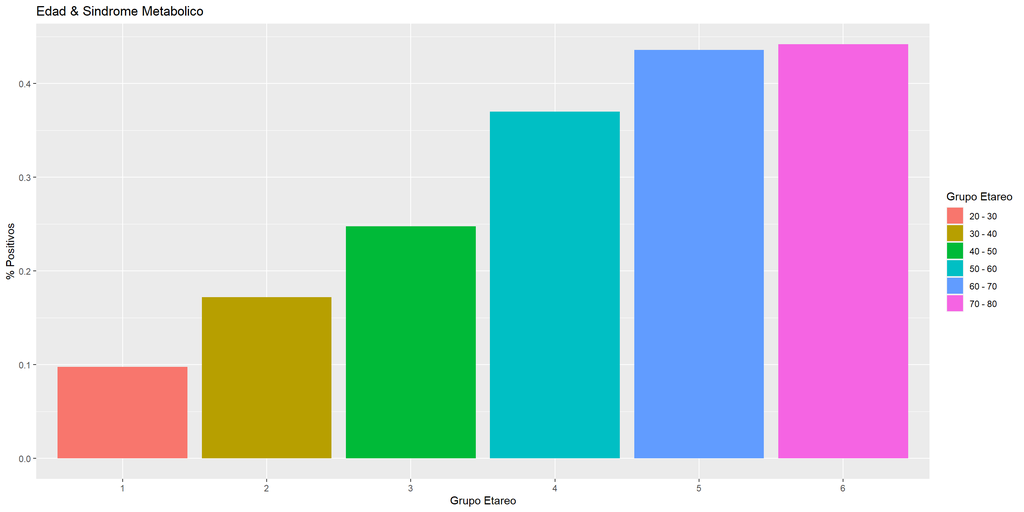

```r
edad_metabolico <- df_procesada %>% group_by(etareo) %>%
  summarise(positivos = sum(metabolico == 1) / n(), negativos = sum(metabolico == 0) / n())

ggplot(data = edad_metabolico %>% inner_join(edad_ref)) +
  geom_col(mapping = aes(x = etareo, y = positivos, fill = etiqueta_edad)) +
    labs(title = "Edad & Sindrome Metabolico", x = "Grupo Etareo", y = "% Positivos") +
        guides(fill = guide_legend(title = "Grupo Etareo"))
```

Se puede observar que la proporción de pacientes afectados aumenta con la edad, por lo que la posibilidad de dicha correlación es sensata.

#### Alguno de los 2 sexos es determinante a la hora de padecer síndrome metabólico?

```r
sexo_metabolico <- df_procesada %>%
  inner_join(sexo_ref) %>%
    group_by(etiqueta_sexo) %>% summarise(positivo = sum(metabolico == 1),
                                                  negativo = sum(metabolico == 0),
                                                    total = n(),
                                                      positivo_tasa = positivo / total,
                                                        negativo_tasa = negativo / total)
```

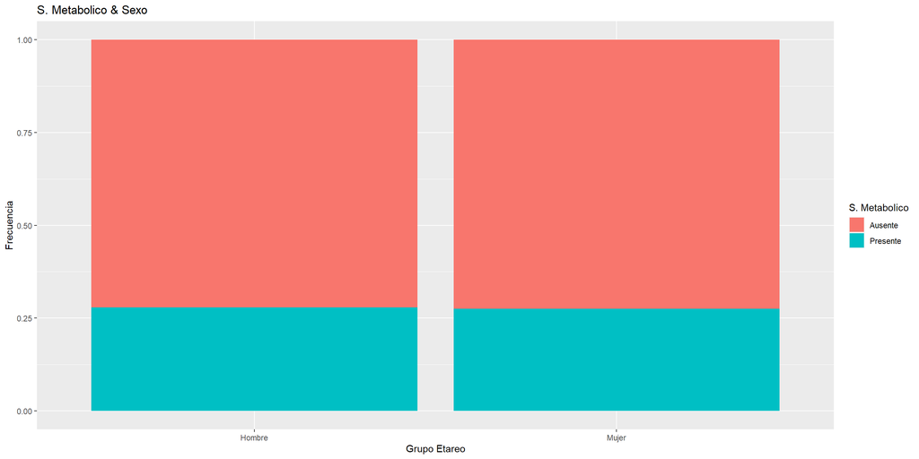

```r
ggplot(data = df_procesada %>% inner_join(sexo_ref) %>% inner_join(metabolico_ref)) +
  geom_bar(mapping = aes(x = etiqueta_sexo, fill = etiqueta_metabolico), position = "fill") +
    labs(title = "S. Metabolico & Sexo", x = "Grupo Etareo", y = "Frecuencia") +
        guides(fill = guide_legend(title = "S. Metabolico"))
```

Desde una perspectiva gráfica, no parece haber un sexo predominante.

#### Que ocurre en el caso de la etnia?

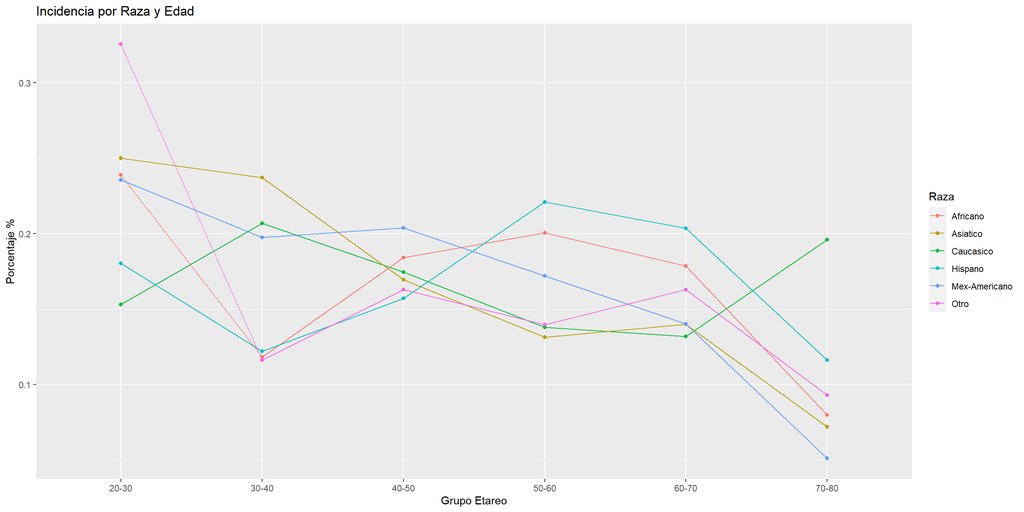

```r
incidencia_raza <- df_procesada %>% group_by(raza) %>% summarise("20-30" = sum(etareo == 1) / n(),
                                                                 "30-40" = sum(etareo == 2) / n(),
                                                                 "40-50" = sum(etareo == 3) / n(),
                                                                 "50-60" = sum(etareo == 4) / n(),
                                                                 "60-70" = sum(etareo == 5) / n(),
                                                                 "70-80" = sum(etareo == 6) / n())

incidencia_raza_long <- pivot_longer(incidencia_raza, cols = `20-30`:`70-80`, names_to = "Grupo Etareo", values_to = "Proporcion")

ggplot(data = incidencia_raza_long %>% inner_join(raza_ref), aes(x = as.factor(`Grupo Etareo`), y = Proporcion, group = raza, color = factor(etiqueta_raza))) +
  geom_line() +
    geom_point() +
      labs(title = "Incidencia por Raza y Edad", x = "Grupo Etareo", y = "Porcentaje %") +
        guides(color = guide_legend(title = "Raza"))
```

Algo similar podría ocurrir en la segunda mitad, pero al revés. Pese a todo, también es factible que la reducción de la incidencia en grupos minoritarios se deba a que efectivamente cuentan con un factor protector, o bien, no cuentan con el factor de riesgo que si estaría presente en el grupo caucásico.

#### El aumento de la grasa visceral abdominal se relaciona con trigliceridemia?

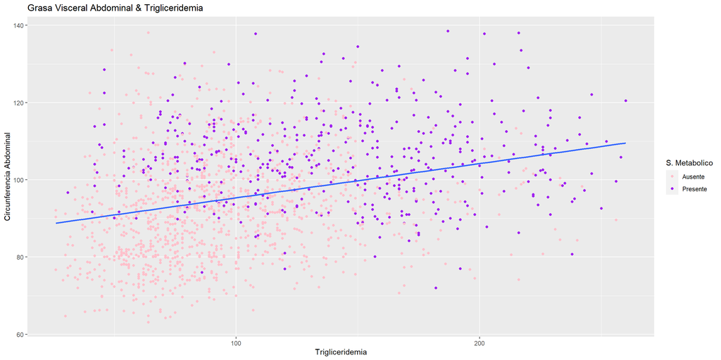

```r
ggplot(data = df_procesada) +
  geom_point(mapping = aes(x = trigliceridemia, y = abdomen, color = metabolico)) +
    geom_smooth(method = "lm", formula = y ~ x, se = FALSE, mapping = aes(x = trigliceridemia, y = abdomen)) +
      labs(title = "Grasa Visceral Abdominal & Trigliceridemia", x = "Trigliceridemia", y = "Circunferencia Abdominal") +
        scale_color_manual(values = c("0" = "pink", "1" = "purple"), labels = c("Ausente", "Presente")) +
          guides(color = guide_legend(title = "S. Metabolico"))
```

Existe una leve-moderada correlación positiva entre ambas variables.

#### La trigliceridemia se relaciona con glucemia?

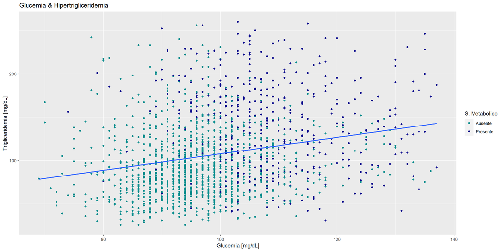

```r
ggplot(data = df_procesada) +
  geom_point(mapping = aes(x = glucemia, y = trigliceridemia, color = metabolico)) +
    geom_smooth(method = "lm", formula = y ~ x, se = FALSE, mapping = aes(x = glucemia, y = trigliceridemia)) +
      labs(title = "Glucemia & Hipertrigliceridemia", x = "Glucemia [mg/dL]", y = "Trigliceridemia [mg/dL]") +
        scale_color_manual(values = c("0" = "darkcyan", "1" = "darkblue"), labels = c("Ausente", "Presente")) +
          guides(color = guide_legend(title = "S. Metabolico"))
```

Existe una leve-moderada correlación positiva entre ambas variables.

### Clústeres

En este segmento se probaran diferentes modelos de aprendizaje automático. Se evaluara cual se ajusta mejor a los datos etiquetados, y se intentara justificar que dicha clasificación no necesariamente sera la única útil en el contexto del síndrome.

#### Pre-Procesamiento

Se aplicara sobre una porción del DF (el proceso de estandarización)

```r
# Estandarizan de un subgrupo de variables cuantitativas
sub_df_mod_cuan <- df_procesada %>%
  select(abdomen, imc, glucemia, trigliceridemia, hdl, uricemia) %>%
    scale() %>% as.data.frame()
```

#### Aplicando el modelo K-Means

En este caso, se partirá de la idea de desconocer el numero de grupos pre-establecidos, para reconocer potencial nueva información. En otras palabras, se permitirá al modelo encontrar el mejor numero de clusteres en función del cambio de variabilidad intra-grupo (WithinSS).

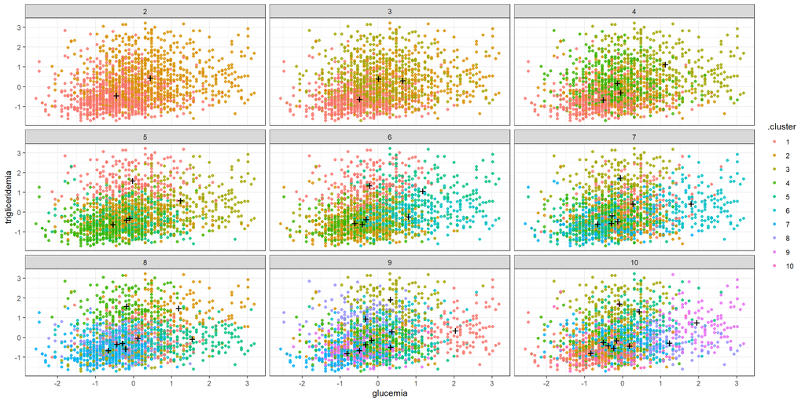

```r
# Iterando para encontrar el numero de clusteres ideal
kclusts <- tibble(k = 2:10) %>%
  mutate(
    kclust = map(k, ~ kmeans(sub_df_mod_cuan, .x)),
    tidied = map(kclust, tidy),
    glanced = map(kclust, glance),
    augmented = map(kclust, augment, sub_df_mod_cuan)
  )

# Desanidando los resultados: clusters
clusters <- kclusts %>%
  unnest(cols = c(tidied)) %>%
  select(-c(glanced, augmented, kclust))

# Desanidando los resultados: predicciones
predicciones <- kclusts %>%
  unnest(cols = c(augmented)) %>%
  select(k, abdomen, imc, glucemia, trigliceridemia, hdl, uricemia, .cluster)

# Desanidando los resultados: resumen
resumen <- kclusts %>%
  unnest(cols = c(glanced)) %>%
  select(-c(kclust, tidied, augmented))

# Graficando las posibilidades
ggplot(predicciones, aes(x = glucemia, y = trigliceridemia)) +
  geom_point(aes(color = .cluster), alpha = 0.8) +
    geom_point(data = clusters, size = 5, shape = "+") +
      facet_wrap(~ k) +
        theme_bw()
```

Si bien el objetivo es lograr 2 grupos (positivos y negativos para síndrome metabólico), la realidad es que la medicina podría beneficiarse de subclasificaciones: dado que el síndrome es un continuo, no todos los pacientes podrían necesitar el mismo tratamiento (por ej, las mismas dosis de fármacos). Por lo tanto, la nueva clusterizacion podría aumentar la eficiencia (beneficio en función del costo) del enfoque diagnostico y terapéutico de esta alteración metabólica.

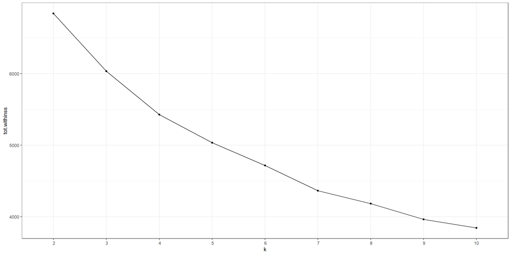

```r
# Graficando la métrica WithinSS a valores crecientes de K
ggplot(resumen, aes(x = k, y = tot.withinss)) +
  scale_x_discrete(name = "k", limits = c(2:10)) +
    geom_point() +
      geom_line () +
        theme_bw()
```

A pesar de lo anterior, la necesidad de nuevos grupos empieza a tornarse menos relevante a partir de k = 3, ya que entre este y k = 2 es donde se observa la mayor caída de la métrica WithinSS (es decir, la variabilidad intragrupo).

```r
# Indicando el numero de clusters de interés
kclust <- kmeans(sub_df_mod_cuan, centers = 3)

# Indicando el cluster asignado, y la distancia de cada variable con el centroide del mismo
augment(kclust, sub_df_mod_cuan)
```

```
## # A tibble: 1,625 × 8
##    .rownames abdomen    imc glucemia trigliceridemia    hdl uricemia .cluster
##    <chr>       <dbl>  <dbl>    <dbl>           <dbl>  <dbl>    <dbl> <fct>
##  1 1         -1.06   -0.824   -0.622          -0.488 -1.03   -0.340  2
##  2 2         -1.12   -0.842   -1.47           -1.08  -2.04   -0.640  2
##  3 3         -1.87   -1.41     0.646          -0.614 -0.875   0.0352 2
##  4 4          1.73    1.02     0.392           0.713  1.45   -0.265  3
##  5 6          1.17    0.133    0.477          -0.151 -0.565  -0.415  3
##  6 7         -1.23   -1.04    -1.04           -1.41   0.520   0.0352 2
##  7 8         -1.12   -0.990   -1.38           -0.340 -0.488   1.01   1
##  8 12         0.0718 -0.566   -0.453           1.58   0.287   1.01   1
##  9 13         0.709   0.207    0.139           0.460 -1.11    2.58   1
## 10 14        -0.940  -1.03    -0.706          -0.951 -0.643  -0.640  2
## # ℹ 1,615 more rows
```

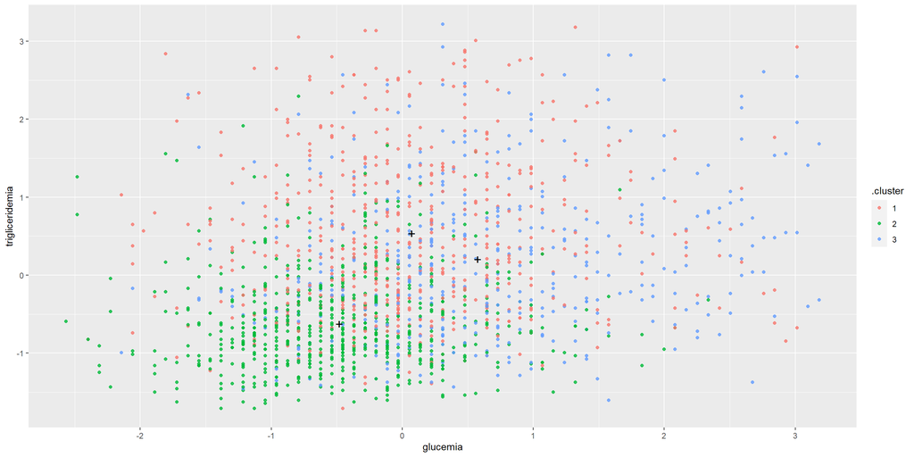

```r
# Graficando
ggplot(augment(kclust, sub_df_mod_cuan), aes(x = glucemia, y = trigliceridemia)) +
  geom_point(aes(color = .cluster), alpha = 0.8) +
    geom_point(data = tidy(kclust), size = 5, shape = "+")
```

#### Aplicando el modelo de Clusterización Jerarquica

En este caso, se probara el modelo de clusterizacion jerarquica en busca de la capacidad del algoritmo para lograr la clasificacion pre-establecida (positivos y negativos para sindrome metabolico).

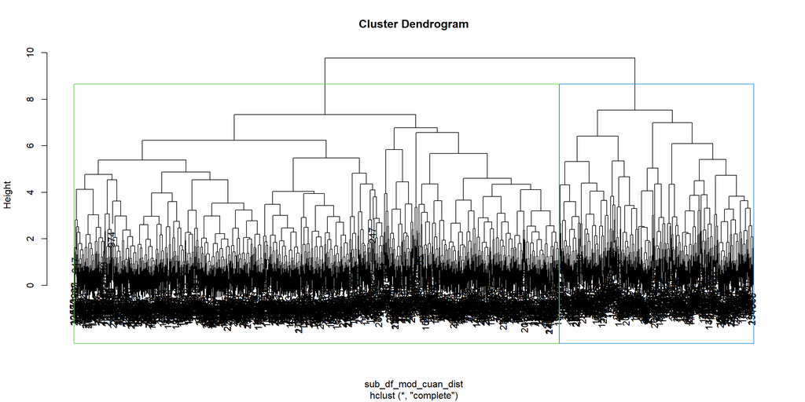

```r
# Generando una matriz de distancia
sub_df_mod_cuan_dist <- sub_df_mod_cuan %>% # Se crea la matriz de distancia sobre el df estandarizado
  dist()

# Logrando el modelo de clusterizacion jerárquica
hc <- hclust(sub_df_mod_cuan_dist, method = "complete") # El primer argumento es la matriz de distancia

# Visualización gráfica: dendograma
plot(hc)
rect.hclust(hc, k = 2, border = 3:4) # (modelo, clusters, colores)
```

En este caso buscamos comparar la precisión del modelo: por lo tanto, se contrastaran los datos modelados con los datos originales.

```r
# "Cortando" el árbol para facilitar su visualización
clusters <- cutree(hc, k = 2) # Dado que son 2 los grupos objetivo (positivo y negativo para SM)
cj_results <- table(clusters, df_procesada$metabolico) # Comparando los grupos resultantes: dendograma vs. datos originales

cj_results_table <- as.data.frame(cj_results)

negatives <- cj_results_table$Freq[[1]]
false_negatives <- cj_results_table$Freq[[2]]
false_positives <- cj_results_table$Freq[[3]]
positives <- cj_results_table$Freq[[4]]

total_1 <- negatives + false_negatives
total_2 <- positives + false_positives
negatives_per <- negatives / (negatives + false_negatives)
positives_per <- positives / (positives + false_positives)

cj_results
```

```
##
## clusters   0   1
##        1 971 189
##        2 204 261
```

En este primer análisis por jerarquización, observamos:

[output not shown]

Se repetira el modelado, pero cambiando los hiperparametros de clusterizacion:

```r
# Probando diferentes métodos de clusterizacion

# Creando la lista de métodos a iterar
cluster_method <- c("average", "single", "complete", "ward")
names(cluster_method) <- cluster_method

# Creando una lista con los resultados de los diferentes métodos de clusterizacion
hc_list <- purrr::map(
  .x = cluster_method, # lista de métodos sobre los cuales iterar
  .f = function(x) {
    agnes(sub_df_mod_cuan_dist, method = x) # función que tomara el método de la lista de métodos
  }
)
```

| Hiperparametro de Clasificación | Coeficiente Aglomerativos |
| --- | --- |
| Average | 0.8243605 |
| Single | 0.6401309 |
| Complete | 0.9202103 |
| Ward | 0.9892169 |

Se puede observar como el método Ward es el de mejor rendimiento. Por lo tanto se procede a rehacer el modelado utilizando dicho hiperparametro:

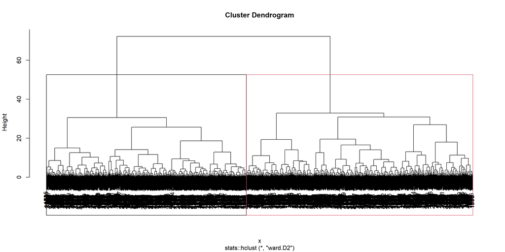

```r
# Repito el modelado con el hiperparámetro mas preciso (en este caso, $Ward)
hc_ward <- hcut(sub_df_mod_cuan_dist, k = 2, hc_method = "ward.D2")
plot(hc_ward)
rect.hclust(hc_ward, k = 2, border = 1:2)
```

```r
# Comparando el resultado de la clusterizacion con los datos etiquetados
table(hc_ward$cluster, df_procesada$metabolico)
```

```
##
##       0   1
##   1 708  54
##   2 467 396
```

### Análisis de Componente Principal (PCA)

Si bien el número de columnas con las que cuenta el set de datos es escasa, en el análisis fisiopatológico es valido suponer que existe colinealidad y multicolinealidad entre las variables (ej, la hipertrigliceridemia esta correlacionada positivamente con la hiperglucemia).

Para reducir el ruido que puede introducir en el modelado de datos, se aplicaran técnicas de Análisis de Componente Principal. Esto además facilitara la proyección del conjunto de datos en gráficos bidimensionales que resuman, si el análisis así lo determina, las características de los mismos.

```r
colnames(sub_df_mod_cuan)
```

```
## [1] "abdomen"         "imc"             "glucemia"        "trigliceridemia"
## [5] "hdl"             "uricemia"
```

```r
pca_metabolic <- sub_df_mod_cuan %>%
  prcomp(., center = TRUE, scale = FALSE) # Evitando el escalado, ya que los datos ya lo están.

pca_metabolic_summary <- summary(pca_metabolic)
```

#### Scree Plot

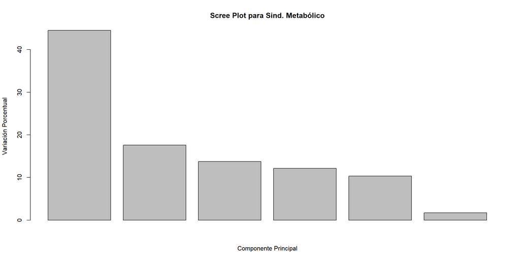

```r
# Autovalores y Autovectores
autovectores <- pca_metabolic$rotation

autovalores <- pca_metabolic$sdev * pca_metabolic$sdev
# Eigenvalues (promedio de SS(distancia) para cada PCA)
# Para lograrlos, hay que potenciar los Singular Value (equivalente a la sdev)

# Calculo del porcentaje explicado
pca_var_pct <- round(autovalores / sum(autovalores) * 100, digits = 2)
barplot(pca_var_pct, main = "Scree Plot para Sind. Metabólico", xlab = "Componente Principal", ylab = "Variación Porcentual")
```

#### Scatter Plot

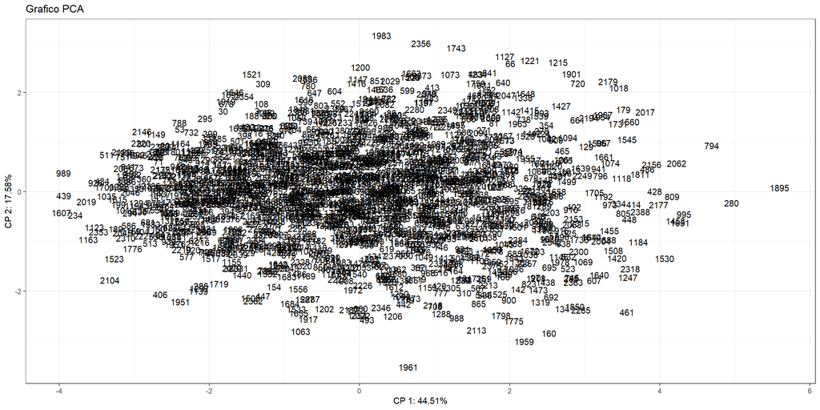

```r
# Calculo del porcentaje explicado
pca_var_pct <- round(autovalores / sum(autovalores) * 100, digits = 2)

# Creando el modelo para el gráfico
pca_data <- data.frame(
  row_names = rownames(pca_metabolic$x),
  x = pca_metabolic$x[,1],
  y = pca_metabolic$x[,2]
)

# Graficando
ggplot(pca_data, aes(x, y, label = row_names)) +
  geom_text() +
    xlab(paste0("CP 1: ", pca_var_pct[1], "%")) +
      ylab(paste0("CP 2: ", pca_var_pct[2], "%")) +
        theme_bw() +
          ggtitle("Grafico PCA")
```

Se puede observar que efectivamente se perdió cualquier tendencia en la dispersión de los datos.

#### Biplot

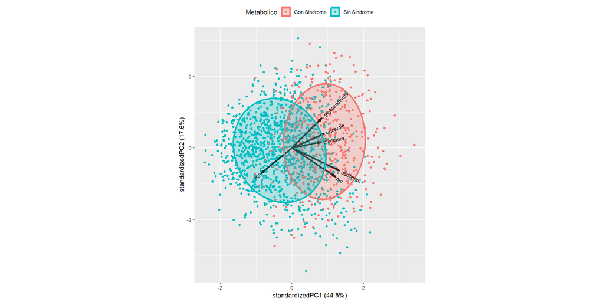

```r
df_procesada$metabolico <- ifelse(df_procesada$metabolico == 0, "Sin Sindrome", "Con Sindrome")

ggbiplot(pca_metabolic, ellipse = TRUE, labels = rownames(pca_metabolic), groups = df_procesada$metabolico) +
  labs(fill = "Metabolico", color = "Metabolico") +
    theme(legend.direction = 'horizontal', legend.position = 'top')
```

La **presencia** del mismo se relaciona con valores altos de:  
- Trigliceridemia  
- Glucemia  
- Uricemia  
- *Circunferencia Abdominal* (“Abdomen”)  
- IMC

La **ausencia** del mismo, a su vez, con valores elevados de:  
- HDL

Esto, ademas, **se corresponde** con el conocimiento de la fisiopatológia del síndrome.